# Data Preparation and Exploration

8/15/2017

## Introduction

1. The Case
2. Learning Goals
3. The Data Science Process
4. The Tidyverse

## The Case

- AirBnB is a website that allows hosts to rent their homes to travelers and tourists.
- AirBnB can maximize its business by ensuring it has enough listings in different neighborhoods.
- AirBnB has asked you, a data analytics consultant, to help them identify neighborhoods in Boston where they should focus on recruitment through advertising and incentives.
- They have given you a complex, multi-part data set to answer this question.

## What We'll Do This Morning

- Work with real and interesting data
- Create appealing and informative visualizations
- Draw useful conclusions

[*David Robinson*](http://varianceexplained.org/r/teach-tidyverse/)

## Exercise 0

1. Look left.
2. Look right.
3. Pick a partner.
4. Give them a professional, yet friendly smile. You are going to need them soon.

## FYI: Base `R`

- `R` without any packages offers ways to do most of the things we will see today.
- But base `R` is not a very good programming language.
- So, we will use….

## The Tidyverse

- "Programs must be written for people to read and only incidentally for machines to execute" - [Hal Abelson](https://en.wikipedia.org/wiki/Hal_Abelson)

The Tidyverse is a set of packages that promote code which is:

- Easy to read and write
- Highly performant
- Consistent across the data science workflow

**When you master the Tidyverse, you spend more time thinking about your problem and less time thinking about your code.**

## The Process of Data Science

[figure not shown]

## Getting Started

1. Data Import and Inspection
2. Data Subsetting
3. The Pipe

## Our Data Today

AirBnB listings, schedule, and review text for the Boston area, for a time period…that you will check.

```r
library(tidyverse)
listings <- read_csv('../data/listings.csv')
calendar <- read_csv('../data/calendar.csv')
```

## Warmup: The Nicest Places in JP

- **Question:** What are the "nicest" places to stay in Jamaica Plain?
- **Task:** Construct a table of listings in JP, sorted in descending order by rating.

Conceptually, we need to: `filter` to only JP listings, `arrange` the listings by rating, and `select` only the columns we want to see. Let's write some code!

You are going to spend a long weekend in Back Bay with 50 of your closest friends.

Working with your partner, modify your code slightly to construct a table of the listings in Back Bay, sorted by the number of people who can stay there. You may need to use `glimpse` to see which columns you'll want to use.

## Exercise 1: Sample Code

```r
listings %>%
    filter(neighbourhood == 'Back Bay') %>%
    arrange(accommodates) %>%
    select(neighbourhood, name, accommodates, price)
```

## Exercise 1: Sample Output

[output not shown]

[output cut: 281 more lines]

## Summarising Data

1. Summary Statistics
2. Adding Columns
3. Grouping

## `summarise`

## `group_by`

## `mutate`

## Exercise

## Sample Solution: Code

```r
summary_table <- listings %>%
    mutate(price = as.numeric(gsub('\\$|,', '', price)),
           price_per = price / accommodates) %>%
    group_by(neighbourhood) %>%
    summarize(n = n(),
              mean_rating = mean(review_scores_rating, na.rm = TRUE),
              price_per = mean(price_per, na.rm = TRUE))
```

## Sample Solution: Output

|  | neighbourhood | n | mean_rating | price_per |
| --- | --- | --- | --- | --- |
| 1 | Allston-Brighton | 364 | 90.0671641791045 | 48.7384793777651 |
| 2 | Back Bay | 291 | 91.5318181818182 | 81.3209540173458 |
| 3 | Beacon Hill | 174 | 93.8116883116883 | 86.5166940339354 |
| 4 | Brookline | 8 | 100 | 55.9583333333333 |
| 5 | Cambridge | 7 | 74.5 | 55.4821428571429 |
| 6 | Charlestown | 79 | 94.1475409836066 | 78.6552139843279 |
| 7 | Chestnut Hill | 4 | 90 | 49.5 |
| 8 | Chinatown | 78 | 92.3777777777778 | 65.5643162393162 |
| 9 | Dorchester | 195 | 89.5798816568047 | 41.5957610907611 |
| 10 | Downtown | 8 | 83.2857142857143 | 59.5416666666667 |

[output cut: 21 more lines]

## Keeping Current

1. More practice with `filter` and `summarise`
2. `join`ing data

## How Current Is This Info?

```r
calendar %>%
    summarise(earliest = min(date),
           latest = max(date))
```

```
## # A tibble: 1 x 2
##     earliest     latest
##       <date>     <date>
## 1 2016-09-06 2017-09-05
```

## Exercise

*Hint:* You can represent a date using the function

```r
lubridate::mdy('6/1/2016')
```

```
## [1] "2016-06-01"
```

You can also use `lubridate::today()`. You can use `max()` to get the most recent date.

## Sample Solution: Code

```r
current_table <- calendar %>%
    filter(!is.na(price),
           date < lubridate::today(),
           date > lubridate::mdy('6/1/2016')) %>%
    group_by(listing_id) %>%
    summarise(last_active = max(date))
```

## Sample Solution: Output

|  | listing_id | last_active |
| --- | --- | --- |
| 1 | 3353 | 2017-08-16 |
| 2 | 5506 | 2017-08-16 |
| 3 | 6695 | 2017-08-16 |
| 4 | 6976 | 2017-08-16 |
| 5 | 8792 | 2017-08-16 |
| 6 | 9273 | 2017-08-16 |
| 7 | 9765 | 2017-08-16 |
| 8 | 9824 | 2017-08-16 |
| 9 | 9855 | 2017-08-16 |
| 10 | 9857 | 2017-08-16 |

[output cut: 2877 more lines]

## Relational Data

The information we need is distributed between two tables – how can we get there?

We need a key that tells us which `calendar` rows correspond to which `listings`.

## `join`

The `join` family of functions lets us add columns from one table to another using a key.

We'll use `left_join` for this case.

## Getting Visual

1. Graphical Excellence
2. The Grammar of Graphics
3. Wrangling and Visualization

## Graphical Excellence

> Graphical excellence is the well-designed presentation of interesting data – a matter of *substance*, of *statistics*, and of *design*. Graphical excellence consists of complex ideas communicated with clarity, precision, and efficiency. – *Edward Tufte*

## The Grammar of Graphics

A **grammar** is a set of components (ingredients) that you can combine to create new things. Many grammars have **required components**: if you're missing one, you're doing it wrong. In baking….

- **A body** – typically some kind of flour)
- **Binder** – eggs, oil, butter, or applesauce
- **A rising agent** – yeast, baking soda, baking powder
- **Flavoring** – sugar, salt, chocolate, vanilla

[figure not shown]

## The Grammar of Graphics

- Puts the `gg` in `ggplot2`.
- Formulated by Leland Wilkinson.
- Implemented in code by Hadley Wickham, now part of the `tidyverse`

[figure not shown]

## Ingredients of a data visualization

- **`Data`**: almost always a `data_frame`
- **`Aes`**thetic mapping: relation of data to chart components.
- **`Geom`**etry: specific visualization type? E.g. line, bar, heatmap?
- **`Stat`**istical transformation: how should the data be transformed or aggregated before visualizing?
- **`Theme`**: how should the non-data parts of the plot look?
- Misc. other options.

**Data, aesthetics, and geometries** are the required grammatical components that you always need to specify.

## First Plot

Does getting **lots** of reviews usually mean you get **good** reviews?

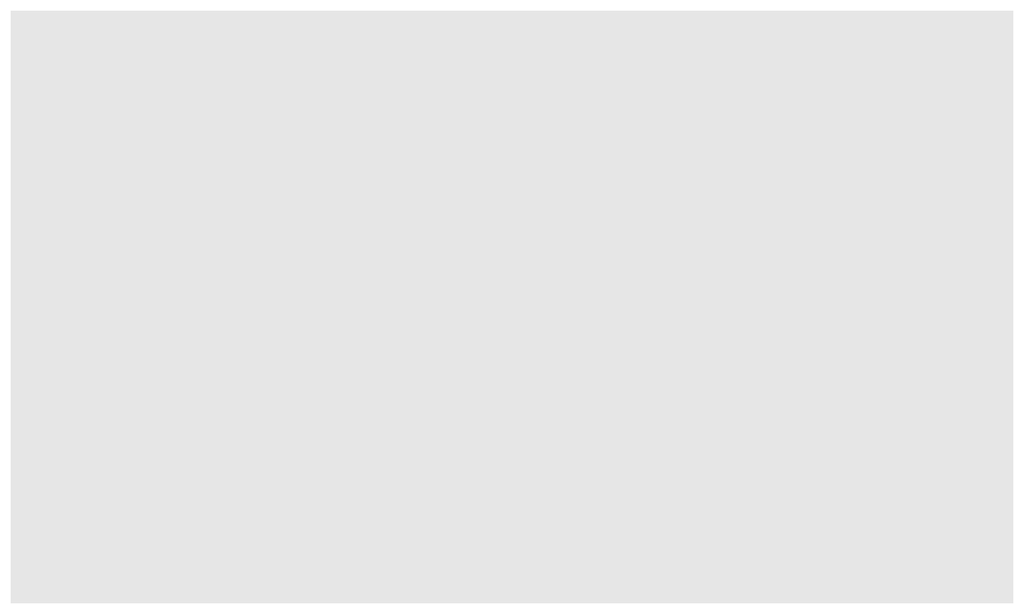

```r
listings %>%
    ggplot()
```

## First Plot

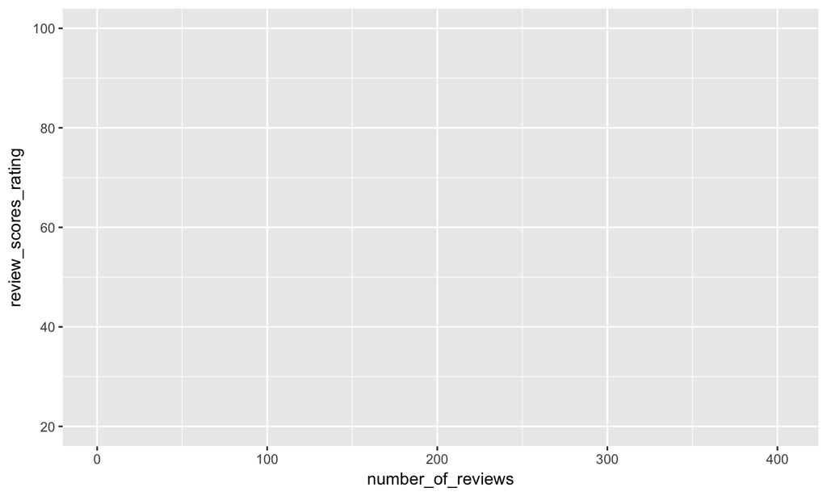

```r
listings %>%
    ggplot() +
    aes(x = number_of_reviews, y = review_scores_rating)
```

## First Plot

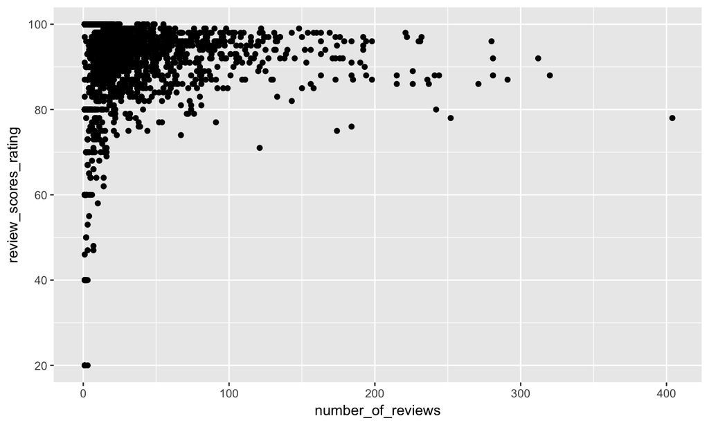

```r
listings %>%
    ggplot() +
    aes(x = number_of_reviews, y = review_scores_rating) +
    geom_point()
```

## First Plot

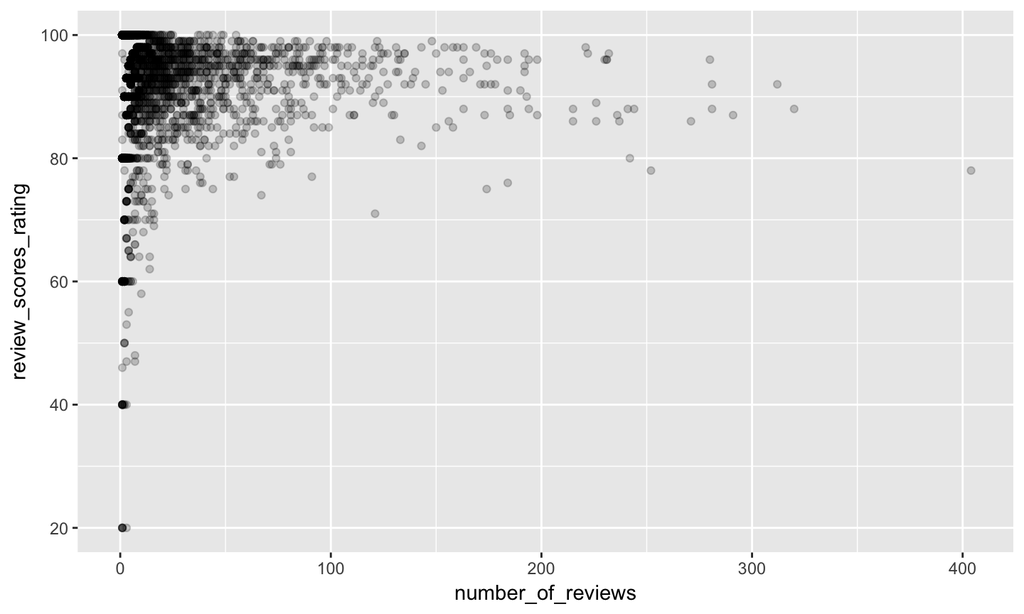

```r
listings %>%
    ggplot() +
    aes(x = number_of_reviews, y = review_scores_rating) +
    geom_point(alpha = .2)
```

## First Plot

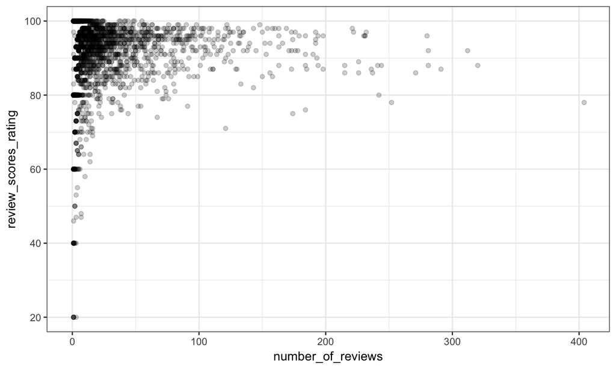

```r
listings %>%
    ggplot() +
    aes(x = number_of_reviews, y = review_scores_rating) +
    geom_point(alpha = .2) +
    theme_bw()
```

## First Plot

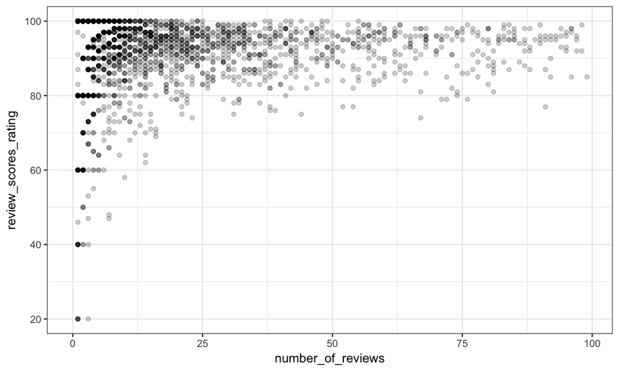

```r
listings %>%
    filter(number_of_reviews < 100) %>%
    ggplot() +
    aes(x = number_of_reviews, y = review_scores_rating) +
    geom_point(alpha = .2) +
    theme_bw()
```

## First Plot

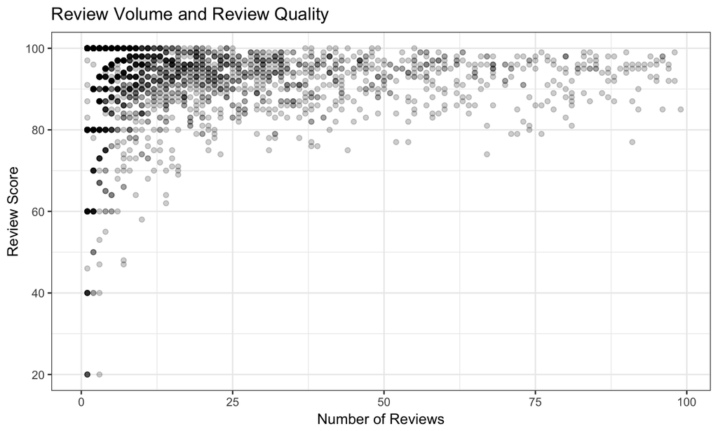

```r
listings %>%
    filter(number_of_reviews < 100) %>%
    ggplot() +
    aes(x = number_of_reviews, y = review_scores_rating) +
    geom_point(alpha = .2) +
    theme_bw() +
    labs(x='Number of Reviews', y='Review Score', title='Review Volume and Review Quality')
```

## First Plot

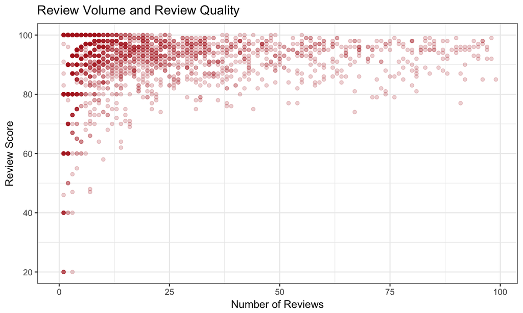

```r
listings %>%
    filter(number_of_reviews < 100) %>%
    ggplot() +
    aes(x = number_of_reviews, y = review_scores_rating) +
    geom_point(alpha = .2, color = 'firebrick') +
    theme_bw() +
    labs(x='Number of Reviews', y='Review Score',title='Review Volume and Review Quality')
```

## Back to the Case Study

```r
summary_table
```

[output not shown]

## Visualization Problems are Wrangling Problems

> "In my experience, the vast majority of graphing agony is due to insufficient data wrangling." - [Jenny Bryan](http://stat545.com/cm006_tibbles-dplyr-ggplot2.html)

## Reference (might get folded in)

## Additional Resources

- Data Wrangling [Cheatsheet](https://www.rstudio.com/wp-content/uploads/2015/02/data-wrangling-cheatsheet.pdf)

## Map of the Tidyverse

[figure not shown]